# Lecture 5: Percentiles, Quartiles and Standard Deviations (POLS 3316 - Statistics for Political Scientists)

Tom Hanna

## Plan for today

- Go over Problem Set 1 today
- Lab and lecture material combined + More on Standard Deviation and Variance + Percentiles, Deciles, Quartiles, Ranges
- Skipping Matrices and arrays (today) and lists (tomorrow) *These won’t be testable and aren’t needed for the work we’re doing. I’ll give you references on them and put together notebooks like the labs that you can use on your own later.*
- Quiz today
- Work session in R Studio today
- *Note on today’s code: I’m using “echo=False” to make some of the knitted output a little easier to read. This means that to read the code behind the results, you have to go to the .Rmd file. We’ll be switchin back and forth in class.*

$$\\[4in]$$
$$\\[1in]$$

### Measures of Dispersion Continued

Yesterday we covered *variance* in detail and I told you that *standard deviation* is the square root of variance. Why do we care?

#### Example

- Two companies with the same *mean* salary - **$70,000**.
- **Company A** has a variance of 2,500.
- **Company B** has a variance of 250,000.

Assumptions:

- In most companies entry level workers with no seniority are paid the least and workers with the most seniority are paid the most.
- You have the same chance of getting hired at Company A or Company B

*As a new college graduate with interviews at both companies on the same, which is more appealing?*

$$\\[3in]$$

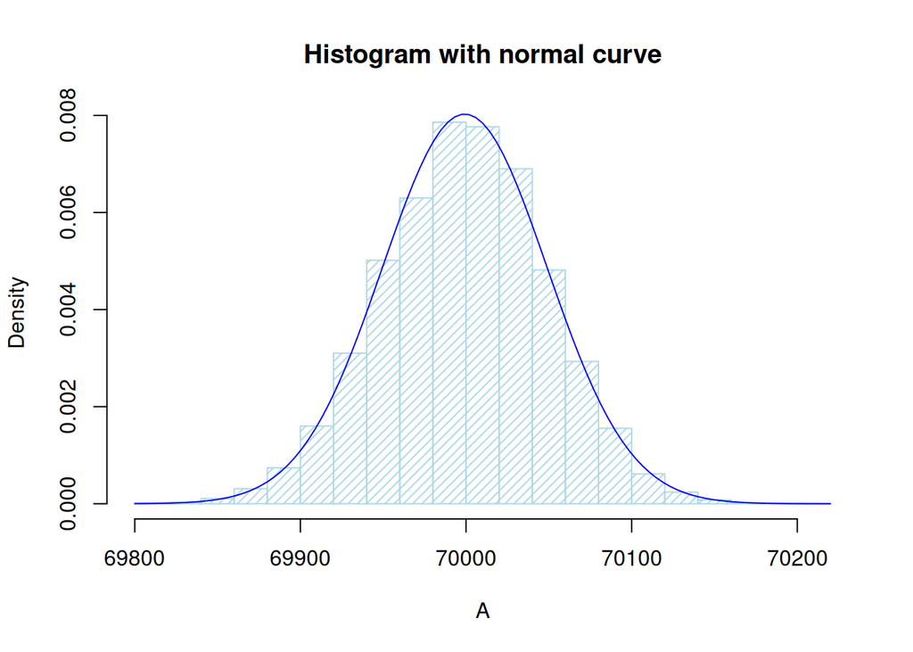

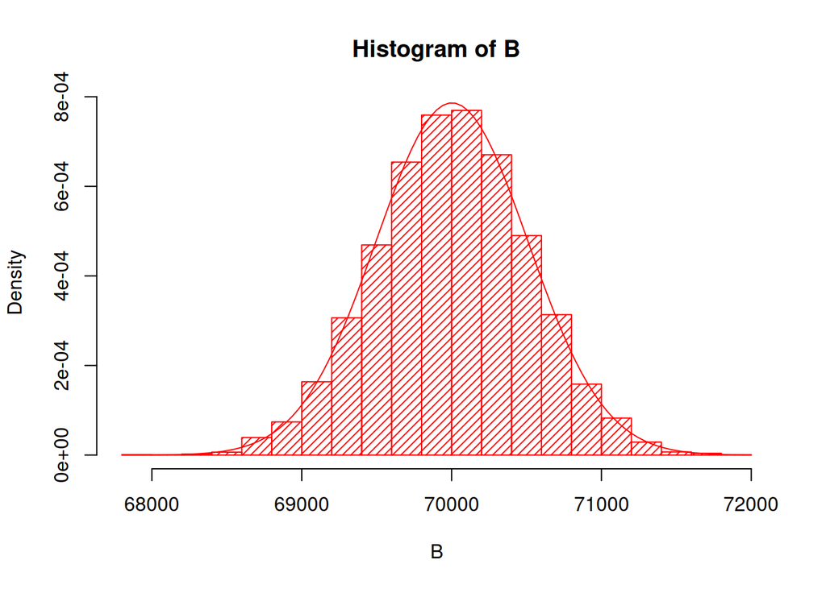

[Adapted from: https://www.dummies.com/article/academics-the-arts/math/statistics/why-standard-deviation-is-an-important-statistic-169731/](https://www.dummies.com/article/academics-the-arts/math/statistics/why-standard-deviation-is-an-important-statistic-169731/)

The answer is pretty obvious, but just working with the variance it’s also overblown. Why?

Because in variance the units are squared!

By taking the square root of the variance, we get back to the original unit of measure. So, in the example:

Company A has a standard deviation of 50.

Company B has a standard deviation of 500.

**One standard deviation from the mean is $69,950 at Company A.**

**One standard deviation from the mean is $69,500 at Company B.**

*Because of some rules we’ll discuss more later, 99.7% of employees are within 3 standard deviations of the mean.*

So, 99.7% of Company A employees make between $69,850 and $70,150 a year.

99.7% of Company B employees make between $68,500 and $71,500 a year.

$$\\[3in]$$

## Other Measures

Here are a few other measures you should be aware of both for **the midterm and final tests** and because they are commonly used:

- **Quartiles**: divides data into four chunks
- **Deciles**: divides into 10 chunks
- **Percentiles**: divides into 100 chunks
- **Interquartile Range**: Between the 1st and 3rd quartiles
- **Minimum**
- **Maximum**
- **Range**: Between the minimum and the maximum

$$\\[4in]$$

#### Examples: Company A and B:

[output not shown]

[output not shown]

```
## Company A
```

```
##
## ======================================================
## 0%            25%        50%        75%        100%
## ------------------------------------------------------
## 69,805.630 69,965.440 69,999.740 70,033.350 70,205.860
## ------------------------------------------------------
```

```
## median A
```

```
## [1] 69999.75
```

```
## Company B
```

```
##
## ======================================================
## 0%            25%        50%        75%        100%
## ------------------------------------------------------
## 67,958.840 69,664.430 70,005.900 70,346.460 71,966.900
## ------------------------------------------------------
```

```
## median B
```

```
## [1] 70005.9
```

$$\\[4in]$$

We can also look at the quartiles visually with a boxplot or whisker plot:

```
## Company A
```

```
## Company B
```

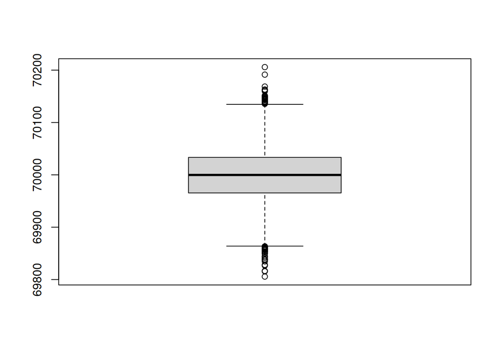

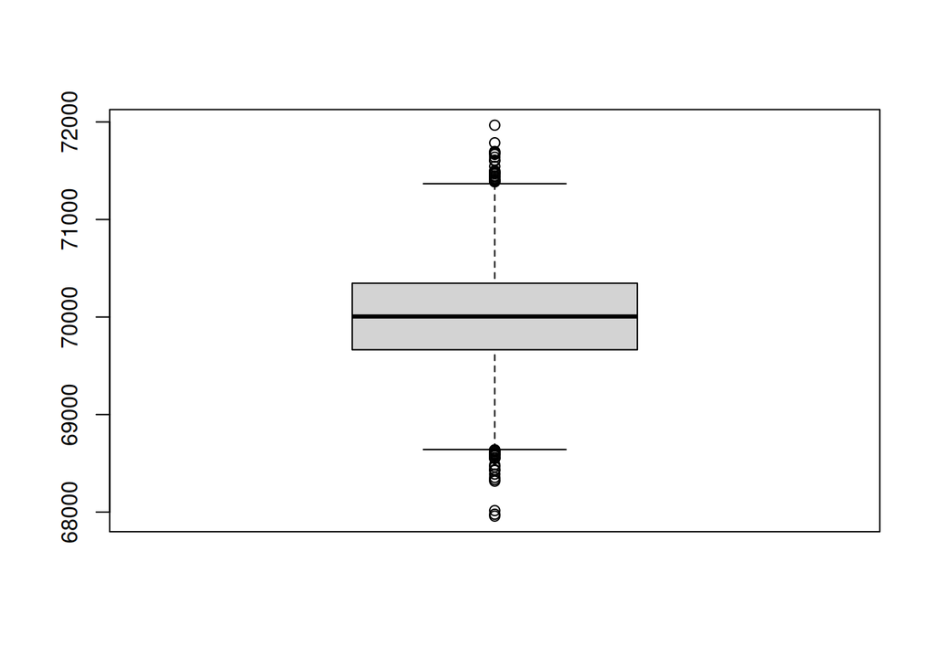

**The bottom line of the box is the first quartile. The top line is the third quartile. The heavy center line is the median. The “whiskers” show the largest or smallest observation that falls within a distance of 1.5 times the box size from the nearest box edge or “hinge”.** In this case, this plot doesn’t really tell us a whole lot, but it can be useful when the distributions are more varied.

$$\\[4in]$$

Let’s look at the deciles:

```
## Company A: Deciles
```

[output not shown]

```
## Company B: Deciles
```

[output not shown]

$$\\[4in]$$

What if we want to know a specific percentile. What if we want to know the top and bottom 1%? That’s the 1st and 99th percentiles:

```r
cat('Top and bottom 1% salaries at Company A')
```

```
## Top and bottom 1% salaries at Company A
```

```r
stargazer(quantile(A, probs = c(.01,.99)), type = "text")
```

```
##
## =====================
## 1%            99%
## ---------------------
## 69,883.270 70,113.590
## ---------------------
```

```r
cat('Top and bottom 1% salaries at Company B')
```

```
## Top and bottom 1% salaries at Company B
```

```r
stargazer(quantile(B, probs = c(.01,.99)), type = "text")
```

```
##
## =====================
## 1%            99%
## ---------------------
## 68,804.120 71,168.830
## ---------------------
```

$$\\[4in]$$

Don’t forget we can also get several summary statistics that include the quartiles with summary():

```r
cat('Company A Summary')
```

```
## Company A Summary
```

```r
#stargazer(summary(A), type = "text")
summary(A)
```

```
##    Min. 1st Qu.  Median    Mean 3rd Qu.    Max.
##   69806   69965   70000   69999   70033   70206
```

```r
cat('\n') #\n is the code for inserting a blank line
```

```r
cat('Company B Summary')
```

```
## Company B Summary
```

```r
summary(B)
```

```
##    Min. 1st Qu.  Median    Mean 3rd Qu.    Max.
##   67959   69664   70006   70002   70346   71967
```